# MCA Analysis using Collective Action Data

Eva Wanjiru

2023-06-20

```r
knitr::opts_chunk$set(message = FALSE, warning = FALSE)
```

**Brief introduction**

This analysis will focus on MCA for dimensionality reduction using Collective Action data collected by a scholar in Kenya. Dimension reduction usually speeds up the training, but it may not always lead to a better or simpler solution. Also, there is a likelihood that we might lose some information through MCA.The categorical features are reduced by the Multiple Correspondence Analysis (MCA), which generates a matrix with values of zero or one. This method binarized categorical variables that have more than two classes.

```r
##load necessary packages
library(tidyverse)
library(naniar)
library(janitor)
library(ggplot2)
library(readxl)
library(summarytools)
library(FactoMineR)
library(factoextra)
require(ClustOfVar)
library(ltm)
library(data.table)
library(psych)
library(polycor)
```

The dataset is first loaded using the read_excel() function and basic checks such as structure and missing values done.

```r
##load the data
MCA_data<-read_excel("MCAData.xlsx")
```

```r
##clean names
df<-MCA_data %>% clean_names()

##missing values
df %>% miss_var_summary()
```

```
## # A tibble: 22 × 3
##    variable                  n_miss pct_miss
##    <chr>                      <int>    <dbl>
##  1 household_head_education       1    0.283
##  2 household_head_gender          0    0
##  3 household_income               0    0
##  4 registration                   0    0
##  5 membership_entry_criteria      0    0
##  6 members_gender                 0    0
##  7 amalgamation                   0    0
##  8 social_networking              0    0
##  9 input_sourcing                 0    0
## 10 output_marketing               0    0
## # ℹ 12 more rows
```

```r
##convert the tibble to a dataframe
df<-as.data.frame(df)

# Rename the dataframe
df_clean <- df

##check first 5 rows
#head(df_clean)

##last 5 rows
#tail(df_clean)

##recode all variables to factors
df_clean[sapply(df_clean, is.character)] <- lapply(df_clean[sapply(df_clean, is.character)],
                                       as.factor)

##structure
str(df_clean)
```

```
## 'data.frame':    353 obs. of  22 variables:
##  $ household_head_gender    : Factor w/ 2 levels "Females","Males": 2 2 2 2 2 2 2 2 2 1 ...
##  $ household_head_education : Factor w/ 5 levels "No formal education",..: 2 5 2 1 5 3 3 3 3 2 ...
##  $ household_income         : Factor w/ 7 levels ">110,001","0 to 10,000",..: 2 2 2 4 2 3 2 2 2 2 ...
##  $ registration             : Factor w/ 2 levels "No","Yes": 2 2 2 2 2 2 2 2 1 2 ...
##  $ membership_entry_criteria: Factor w/ 2 levels "Closed","Open": 2 2 2 1 2 1 1 2 1 1 ...
##  $ members_gender           : Factor w/ 3 levels "Females","Males on",..: 3 3 3 3 3 3 1 3 3 1 ...
##  $ amalgamation             : Factor w/ 2 levels "No","Yes": 1 1 1 2 1 1 1 1 1 2 ...
##  $ social_networking        : Factor w/ 2 levels "No","Yes": 1 1 1 1 1 1 1 1 1 1 ...
##  $ input_sourcing           : Factor w/ 2 levels "No","Yes": 1 2 1 1 1 1 1 1 1 2 ...
##  $ output_marketing         : Factor w/ 2 levels "No","Yes": 1 2 1 1 1 1 1 2 1 2 ...
##  $ extension_services       : Factor w/ 2 levels "No","Yes": 1 2 1 1 1 1 2 1 1 2 ...
##  $ credit_sourcing          : Factor w/ 2 levels "No","Yes": 1 1 1 2 2 1 2 1 1 2 ...
##  $ savings                  : Factor w/ 2 levels "No","Yes": 1 1 1 2 2 1 2 1 2 2 ...
##  $ informal_insurance       : Factor w/ 2 levels "No","Yes": 1 1 1 2 2 1 1 1 1 1 ...
##  $ social_welfare           : Factor w/ 2 levels "No","Yes": 2 1 2 2 2 2 1 1 2 2 ...
##  $ fine_imposing            : Factor w/ 2 levels "No","Yes": 2 1 2 2 2 2 2 1 2 2 ...
##  $ members_trust            : Factor w/ 4 levels "Agree somewhat",..: 1 1 1 2 2 1 2 1 2 2 ...
##  $ other_groups_trust       : Factor w/ 4 levels "Agree somewhat",..: 1 1 4 3 2 4 3 1 3 2 ...
##  $ service_providers_trust  : Factor w/ 4 levels "Agree somewhat",..: 1 1 1 1 1 4 1 4 3 2 ...
##  $ farm_size                : Factor w/ 2 levels "< 2 acres","> 2 acres": 1 1 1 2 1 1 1 1 1 1 ...
##  $ age_groups               : Factor w/ 6 levels "22 to 35","3",..: 5 3 4 3 3 3 3 5 3 5 ...
##  $ groupmembership          : num  1 1 1 1 1 1 1 1 1 1 ...
```

There’s only one missing value in the variable household education and that row can be omitted as it has no much effect on the dataset and analysis. The dataset used in this analysis consists of 353 observations and 22 variables.

**MCA**

```r
res.mca <- MCA(df_clean,graph = FALSE)

##Get Eigen values
eig.val <- get_eigenvalue(res.mca)
eig.val
```

```
##        eigenvalue variance.percent cumulative.variance.percent
## Dim.1  0.17939677        9.6261680                    9.626168
## Dim.2  0.10697518        5.7401315                   15.366299
## Dim.3  0.08508601        4.5655906                   19.931890
## Dim.4  0.08059619        4.3246735                   24.256564
## Dim.5  0.07631675        4.0950452                   28.351609
## Dim.6  0.07079004        3.7984898                   32.150099
## Dim.7  0.06895564        3.7000585                   35.850157
## Dim.8  0.06342515        3.4033006                   39.253458
## Dim.9  0.06125064        3.2866197                   42.540077
## Dim.10 0.05772304        3.0973340                   45.637411
## Dim.11 0.05604685        3.0073921                   48.644804
## Dim.12 0.05188210        2.7839174                   51.428721
## Dim.13 0.05067236        2.7190049                   54.147726
## Dim.14 0.04899204        2.6288410                   56.776567
## Dim.15 0.04673430        2.5076941                   59.284261
## Dim.16 0.04592465        2.4642497                   61.748511
## Dim.17 0.04468232        2.3975881                   64.146099
## Dim.18 0.04278260        2.2956516                   66.441750
## Dim.19 0.04261722        2.2867775                   68.728528
## Dim.20 0.04084406        2.1916327                   70.920161
## Dim.21 0.03965092        2.1276105                   73.047771
## Dim.22 0.03802769        2.0405103                   75.088281
## Dim.23 0.03647962        1.9574428                   77.045724
## Dim.24 0.03529091        1.8936585                   78.939383
## Dim.25 0.03496281        1.8760534                   80.815436
## Dim.26 0.03269428        1.7543272                   82.569763
## Dim.27 0.03260025        1.7492818                   84.319045
## Dim.28 0.02889982        1.5507218                   85.869767
## Dim.29 0.02783426        1.4935456                   87.363312
## Dim.30 0.02703882        1.4508633                   88.814176
## Dim.31 0.02554774        1.3708542                   90.185030
## Dim.32 0.02452055        1.3157367                   91.500767
## Dim.33 0.02319166        1.2444303                   92.745197
## Dim.34 0.02240244        1.2020821                   93.947279
## Dim.35 0.02080948        1.1166063                   95.063885
## Dim.36 0.01919624        1.0300424                   96.093928
## Dim.37 0.01778916        0.9545404                   97.048468
## Dim.38 0.01726955        0.9266589                   97.975127
## Dim.39 0.01474924        0.7914224                   98.766549
## Dim.40 0.01248958        0.6701724                   99.436722
## Dim.41 0.01049746        0.5632783                  100.000000
```

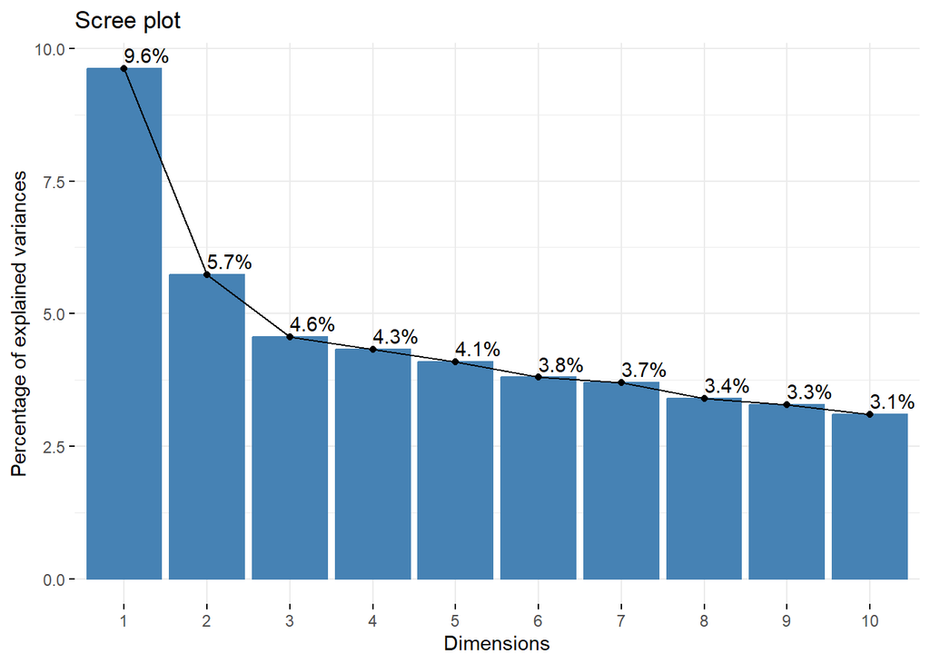

```r
##find percentages explained by MCA dimensions
fviz_screeplot(res.mca, addlabels = TRUE)
```

As shown in the screeplot above, the first two dimensions do not account for more than 20% and all our components have eigen values that are less than 1 and inertia percentage less than 10% hence we need to work around the data to get great results.

```r
##Get variable contributions to the MCA dimensions
var <- get_mca_var(res.mca)


round(var$contrib,2)
```

```
##                                              Dim 1 Dim 2 Dim 3 Dim 4 Dim 5
## household_head_gender_Females                 0.40  0.19  0.77  8.96  3.13
## household_head_gender_Males                   0.18  0.08  0.34  4.00  1.40
## household_head_education.NA                   0.02  0.11  0.46  1.43  0.64
## No formal education                           0.48  1.02  2.70  8.84  0.06
## Primary                                       0.01  4.54  0.08  1.47  3.88
## Secondary                                     0.23  0.32  3.63  0.74  0.61
## University                                    0.01  0.01 13.67  0.18  0.03
## Vocational                                    0.15  0.88  0.10  0.01  0.04
## >110,001                                      0.01  0.25  0.48  0.56  2.20
## 0 to 10,000                                   0.15  0.71  1.35  2.12  0.21
## 10,001 to 30,000                              0.35  1.93  2.29  0.99  0.28
## 30,001 to 50,000                              0.20  0.82  3.68  6.85  0.00
## 50,001 to 70,000                              0.00  0.98  0.01  0.88  0.71
## 70,001 to 90,000                              0.03  0.00  0.08  7.65  7.23
## 90,001 to 110,000                             0.00  0.32  0.01  0.27  0.48
## registration_No                               1.25  3.57  1.61  0.10  0.87
## registration_Yes                              0.18  0.52  0.24  0.01  0.13
## Closed                                        0.00  1.49  0.05  0.01  0.02
## Open                                          0.01 11.04  0.35  0.07  0.15
## members_gender_Females                        4.28  0.69  0.08  0.17  0.50
## members_gender_Males on                       0.02  0.05  0.03  6.87 10.24
## members_gender_Mixed                          5.39  0.78  0.09  0.00  0.05
## amalgamation_No                               2.20  0.28  0.04  0.10  0.11
## amalgamation_Yes                             10.54  1.36  0.20  0.47  0.51
## social_networking_No                          2.56  0.33  0.00  0.58  0.18
## social_networking_Yes                         7.70  0.99  0.00  1.74  0.55
## input_sourcing_No                             1.72  0.06  0.02  0.06  0.00
## input_sourcing_Yes                           11.79  0.43  0.13  0.41  0.03
## output_marketing_No                           3.29  0.00  0.34  0.00  0.00
## output_marketing_Yes                         14.60  0.00  1.50  0.00  0.00
## extension_services_No                         1.36  0.00  0.02  0.06  0.01
## extension_services_Yes                        9.57  0.01  0.15  0.44  0.07
## credit_sourcing_No                            0.37  4.50  1.16  0.00  0.04
## credit_sourcing_Yes                           0.56  6.77  1.75  0.00  0.06
## savings_No                                    3.04  4.21  3.06  0.80  0.00
## savings_Yes                                   1.61  2.22  1.61  0.42  0.00
## informal_insurance_No                         0.16  0.04  0.28  2.16  4.40
## informal_insurance_Yes                        0.38  0.10  0.65  5.10 10.39
## social_welfare_No                             2.86  0.74  0.00  0.27  0.68
```

[output cut: 9 more lines]

```
## other_groups_trust_Disagree strongly          0.58  1.10  8.50  7.93  1.24
## other_groups_trust_Neither agree nor di       0.45  3.34  0.09  3.07  1.74
## service_providers_trust_Agree somewhat        0.03  1.46  0.26  0.09  7.27
## service_providers_trust_Agree strongly        0.04  4.28  2.69  1.41  0.00
## service_providers_trust_Disagree strongly     0.46  0.91  9.75  7.02  0.04
## service_providers_trust_Neither agree nor di  0.00  0.36  9.25  0.06  8.39
## < 2 acres                                     0.04  0.02  0.22  0.48  0.54
## > 2 acres                                     0.54  0.31  3.08  6.60  7.41
## 22 to 35                                      0.72  0.01  0.41  0.03  0.93
## 3                                             0.04  0.05  2.95  0.02  2.53
## 36 to 49                                      0.30  0.14  0.11  2.67  0.24
## 50 to 63                                      0.00  0.19  0.09  0.42  0.59
## 64 to 77                                      0.50  0.58  0.23  0.08  4.05
## Above 70                                      0.31  0.02  0.63  2.16  0.00
## 1                                             0.00  0.00  0.00  0.00  0.00
```

Variables that have higher associations (higher cosine similarity) with specific dimensions are more strongly related to those dimensions. This information can help identify the variables that contribute most to each dimension and understand the underlying patterns in the data.

**Total contribution to dimension 1 and 2**

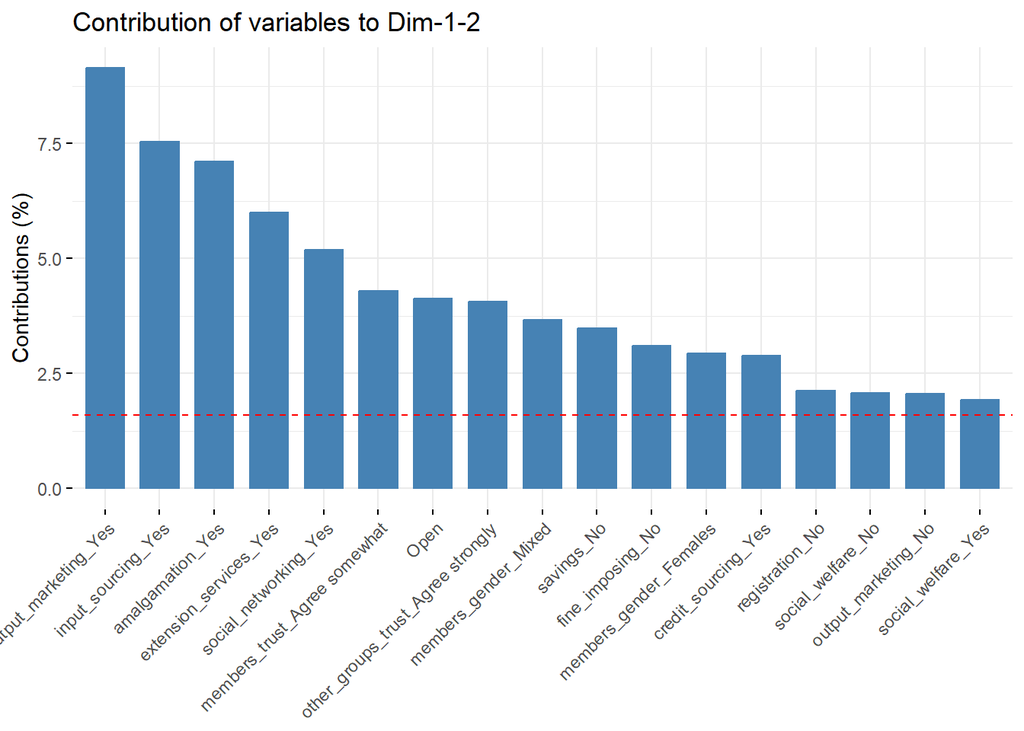

```r
# Total contribution to dimension 1 and 2
fviz_contrib(res.mca, choice = "var", axes = 1:2, top = 17)
```

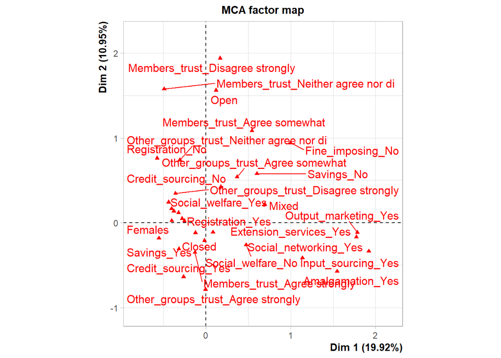

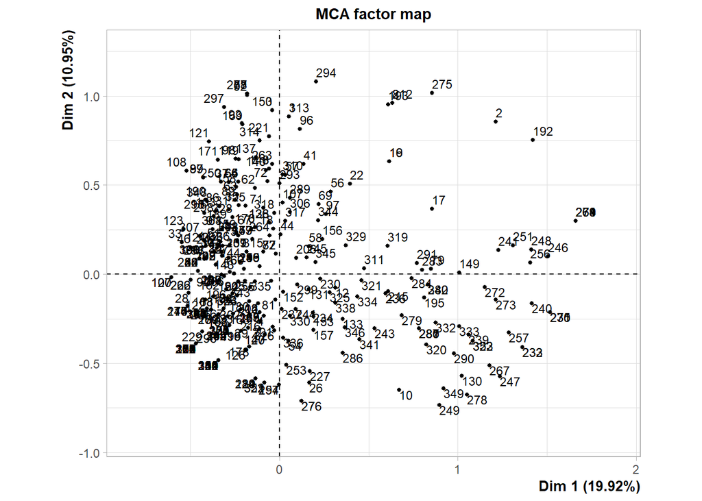

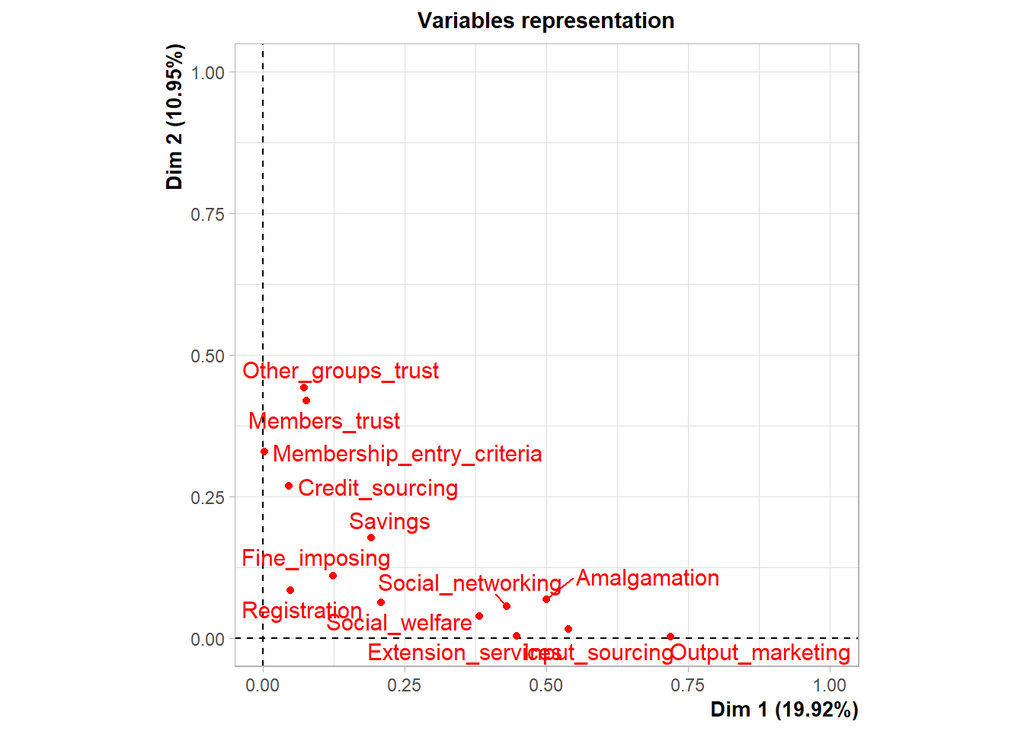

```r
##choose only the top 15 variables
my_data<-MCA_data[,c(4:13,15:18)]
res.mca1 <- MCA(my_data)
```

```r
##Get Eigen values
eig.val1 <- get_eigenvalue(res.mca1)
eig.val1
```

```
##        eigenvalue variance.percent cumulative.variance.percent
## Dim.1  0.27032067        19.918365                    19.91837
## Dim.2  0.14866906        10.954562                    30.87293
## Dim.3  0.09494094         6.995648                    37.86858
## Dim.4  0.08896708         6.555469                    44.42404
## Dim.5  0.07752691         5.712509                    50.13655
## Dim.6  0.07284383         5.367440                    55.50399
## Dim.7  0.06948536         5.119974                    60.62397
## Dim.8  0.06699849         4.936731                    65.56070
## Dim.9  0.06444373         4.748486                    70.30918
## Dim.10 0.06025728         4.440010                    74.74919
## Dim.11 0.05616004         4.138108                    78.88730
## Dim.12 0.05088870         3.749693                    82.63700
## Dim.13 0.04665217         3.437528                    86.07452
## Dim.14 0.04175455         3.076651                    89.15118
## Dim.15 0.03797632         2.798256                    91.94943
## Dim.16 0.03488435         2.570426                    94.51986
## Dim.17 0.03257279         2.400100                    96.91996
## Dim.18 0.02334605         1.720235                    98.64019
## Dim.19 0.01845453         1.359807                   100.00000
```

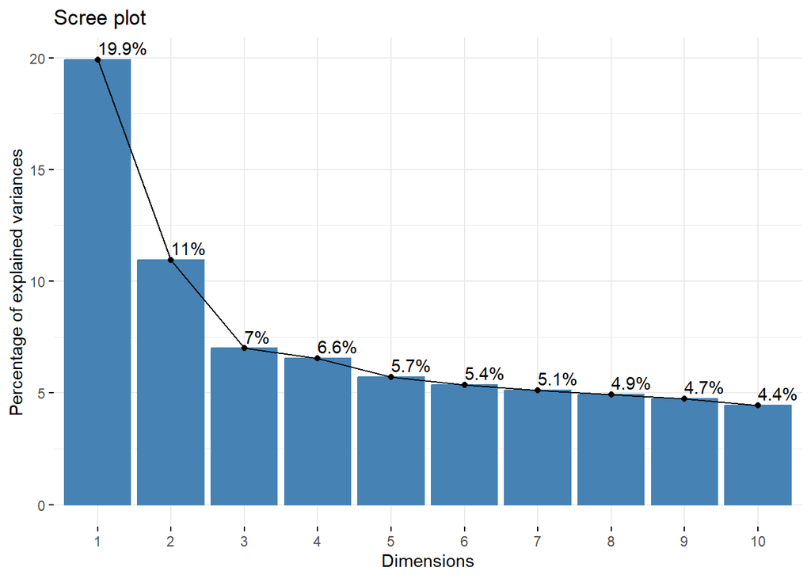

```r
##find percentages explained by MCA dimensions
fviz_screeplot(res.mca1, addlabels = TRUE)
```

Now from the screeplot above, the percentage of inertia explained by each MCA dimension has increased significantly hence we can continue with the analysis.

**Variable contribution to the dimensions**

```r
##Get variable contributions to the MCA dimensions
var_contrib <- get_mca_var(res.mca1)


round(var_contrib$contrib,2)
```

```
##                                         Dim 1 Dim 2 Dim 3 Dim 4 Dim 5
## Registration_No                          1.11  3.54  6.01 15.88  9.11
## Registration_Yes                         0.16  0.52  0.88  2.32  1.33
## Closed                                   0.01  1.88  0.05  0.09  0.22
## Open                                     0.05 13.92  0.38  0.64  1.63
## Females                                  4.40  0.86  0.11  1.01  2.36
## Males on                                 0.06  0.02  0.02  0.33 53.72
## Mixed                                    5.62  1.01  0.15  1.03  0.15
## Amalgamation_No                          2.28  0.57  0.37  0.12  0.23
## Amalgamation_Yes                        10.93  2.72  1.75  0.57  1.10
## Social_networking_No                     2.83  0.68  0.19  0.11  1.16
## Social_networking_Yes                    8.53  2.06  0.59  0.33  3.49
## Input_sourcing_No                        1.81  0.10  0.00  0.00  0.03
## Input_sourcing_Yes                      12.41  0.68  0.00  0.00  0.20
## Output_marketing_No                      3.50  0.03  0.35  0.01  0.13
## Output_marketing_Yes                    15.51  0.11  1.54  0.04  0.59
## Extension_services_No                    1.47  0.02  0.03  0.05  0.06
## Extension_services_Yes                  10.36  0.16  0.24  0.37  0.41
## Credit_sourcing_No                       0.49  5.15  3.51  0.12  0.00
## Credit_sourcing_Yes                      0.73  7.75  5.28  0.17  0.00
## Savings_No                               3.31  5.57  6.05  0.14  5.47
## Savings_Yes                              1.75  2.94  3.19  0.07  2.89
## Social_welfare_No                        2.85  1.57  0.98  2.12  0.09
## Social_welfare_Yes                       2.65  1.46  0.91  1.97  0.08
## Fine_imposing_No                         2.90  4.72  6.72  3.65  1.63
## Fine_imposing_Yes                        0.36  0.59  0.83  0.45  0.20
## Members_trust_Agree somewhat             1.54 11.22 13.95  0.49  0.08
## Members_trust_Agree strongly             0.34  4.49  1.66  0.06  0.12
## Members_trust_Disagree strongly          0.01  2.05 11.92  6.70  0.81
## Members_trust_Neither agree nor di       0.13  2.37  1.35 32.09  5.75
## Other_groups_trust_Agree somewhat        1.01  3.99 17.28  1.83  0.40
## Other_groups_trust_Agree strongly        0.00 12.19  0.65  0.42  0.97
## Other_groups_trust_Disagree strongly     0.49  0.84 12.23 11.30  1.72
## Other_groups_trust_Neither agree nor di  0.41  4.24  0.83 15.53  3.88
```

Variables that have higher associations (higher cosine similarity) with specific dimensions are more strongly related to those dimensions. This information can help identify the variables that contribute most to each dimension and understand the underlying patterns in the data.

**Correlation between variables and principal dimensions**

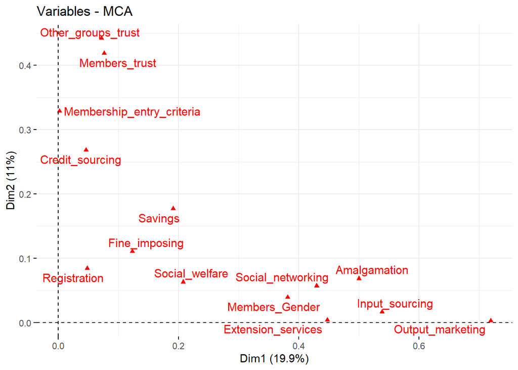

```r
fviz_mca_var(res.mca1, choice = "mca.cor",
            repel = TRUE, # Avoid text overlapping (slow)
            ggtheme = theme_minimal())
```

**Biplot**

A biplot, which combines the dimension plot with the variable plot. This plot allows you to visualize both the relationships between categories and the relationships between variables in the same plot. It helps interpret the associations between categories, variables, and dimensions simultaneously. This can lead to a better understanding of the relationships and provide valuable information for further analysis or decision-making.

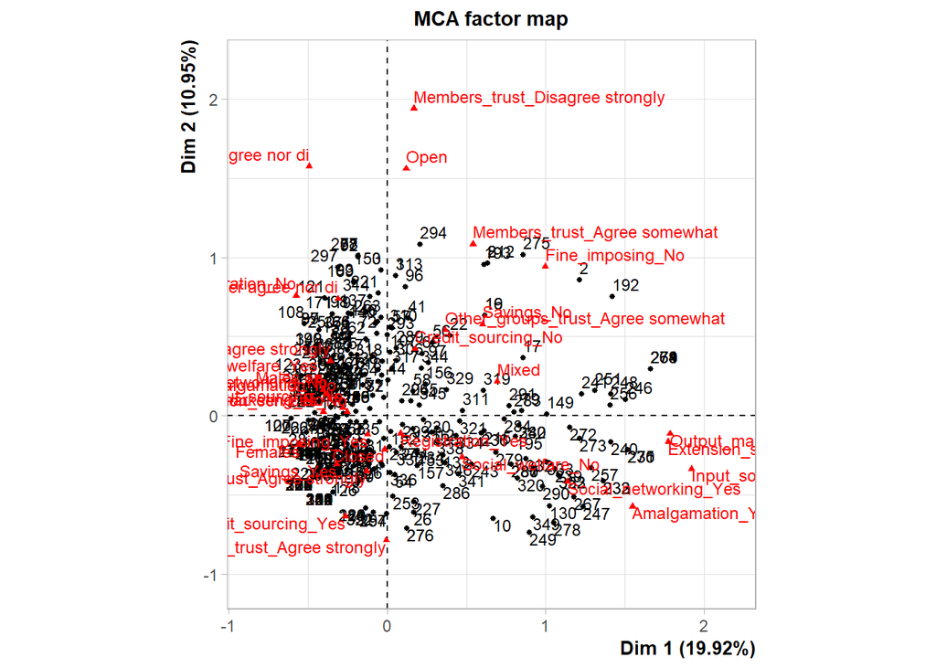

```r
plot.MCA(res.mca1, cex = 0.8,repel = TRUE)
```

```r
var <- get_mca_var(res.mca1)
# Coordinates of variables
var$coord
```

```
##                                                Dim 1       Dim 2        Dim 3
## Registration_No                         -0.574353873  0.76014376  0.791888834
## Registration_Yes                         0.083915339 -0.11105996 -0.115698044
## Closed                                  -0.016234532 -0.21077189  0.027965773
## Open                                     0.120212842  1.56071568 -0.207079889
## Females                                 -0.553067643 -0.18115968 -0.050975390
## Males on                                -0.405035012  0.16648442 -0.123683607
## Mixed                                    0.693680528  0.21762972  0.066703160
## Amalgamation_No                         -0.323175411  0.11948590 -0.076588141
## Amalgamation_Yes                         1.547003607 -0.57196530  0.366618642
## Social_networking_No                    -0.377878263  0.13755920 -0.058657293
## Social_networking_Yes                    1.137928859 -0.41424078  0.176638439
## Input_sourcing_No                       -0.280483436  0.04885134  0.001822715
## Input_sourcing_Yes                       1.919753298 -0.33436026 -0.012475469
## Output_marketing_No                     -0.402911029  0.02561246 -0.075155692
## Output_marketing_Yes                     1.785205790 -0.11348288  0.332997526
## Extension_services_No                   -0.252507721  0.02347714  0.022759253
## Extension_services_Yes                   1.773292860 -0.16487352 -0.159832028
## Credit_sourcing_No                       0.175157505  0.42255972  0.278718126
## Credit_sourcing_Yes                     -0.263357383 -0.63533802 -0.419065550
## Savings_No                               0.601903640  0.57907709  0.482313056
## Savings_Yes                             -0.317888502 -0.30583292 -0.254728107
## Social_welfare_No                        0.473084345 -0.26041560 -0.164838191
## Social_welfare_Yes                      -0.439477260  0.24191613  0.153128374
## Fine_imposing_No                         0.997454575  0.94304648 -0.898920397
## Fine_imposing_Yes                       -0.123887670 -0.11712998  0.111649349
## Members_trust_Agree somewhat             0.542093702  1.08535698 -0.966811512
## Members_trust_Agree strongly            -0.129297167 -0.34839420  0.169369584
## Members_trust_Disagree strongly          0.167555486  1.93892946  3.739337104
## Members_trust_Neither agree nor di      -0.492564525  1.57607366  0.950132941
## Other_groups_trust_Agree somewhat        0.367388072  0.54132189 -0.900497656
## Other_groups_trust_Agree strongly       -0.005613923 -0.78595497  0.145300038
## Other_groups_trust_Disagree strongly    -0.359413507  0.34706016  1.060791122
## Other_groups_trust_Neither agree nor di -0.308678940  0.73914409  0.261068646
##                                                Dim 4         Dim 5
## Registration_No                          1.245767616 -0.8807474633
## Registration_Yes                        -0.182011502  0.1286806359
## Closed                                   0.034834107 -0.0521256988
## Open                                    -0.257938271  0.3859783887
## Females                                  0.152389652 -0.2169710731
```

[output cut: 13 more lines]

```
## Credit_sourcing_Yes                      0.073641257  0.0003710653
## Savings_No                              -0.070506730  0.4143078058
## Savings_Yes                              0.037237321 -0.2188119147
## Social_welfare_No                        0.234297296  0.0449864846
## Social_welfare_Yes                      -0.217653226 -0.0417907234
## Fine_imposing_No                         0.641515026 -0.4007716475
## Fine_imposing_Yes                       -0.079678618  0.0497773702
## Members_trust_Agree somewhat             0.175952029  0.0645977481
## Members_trust_Agree strongly             0.030366141  0.0419529848
## Members_trust_Disagree strongly          2.712906573 -0.8791619198
## Members_trust_Neither agree nor di      -4.489694087 -1.7737723658
## Other_groups_trust_Agree somewhat        0.283329725 -0.1241190097
## Other_groups_trust_Agree strongly       -0.112210894  0.1597558833
## Other_groups_trust_Disagree strongly     0.986818753  0.3597305674
## Other_groups_trust_Neither agree nor di -1.094564022 -0.5105080885
```

```r
# Cos2: quality of representation on the factore map
var$cos2
```

```
##                                                Dim 1        Dim 2        Dim 3
## Registration_No                         4.819710e-02 0.0844215385 9.161999e-02
## Registration_Yes                        4.819710e-02 0.0844215385 9.161999e-02
## Closed                                  1.951599e-03 0.3289549973 5.791149e-03
## Open                                    1.951599e-03 0.3289549973 5.791149e-03
## Females                                 3.647807e-01 0.0391379834 3.098821e-03
## Males on                                2.357089e-03 0.0003982336 2.197936e-04
## Mixed                                   3.810460e-01 0.0375054849 3.523313e-03
## Amalgamation_No                         4.999535e-01 0.0683417894 2.807864e-02
## Amalgamation_Yes                        4.999535e-01 0.0683417894 2.807864e-02
## Social_networking_No                    4.299986e-01 0.0569826315 1.036113e-02
## Social_networking_Yes                   4.299986e-01 0.0569826315 1.036113e-02
## Input_sourcing_No                       5.384590e-01 0.0163339452 2.273922e-05
## Input_sourcing_Yes                      5.384590e-01 0.0163339452 2.273922e-05
## Output_marketing_No                     7.192791e-01 0.0029065752 2.502666e-02
## Output_marketing_Yes                    7.192791e-01 0.0029065752 2.502666e-02
## Extension_services_No                   4.477701e-01 0.0038707579 3.637658e-03
## Extension_services_Yes                  4.477701e-01 0.0038707579 3.637658e-03
## Credit_sourcing_No                      4.612902e-02 0.2684682548 1.168012e-01
## Credit_sourcing_Yes                     4.612902e-02 0.2684682548 1.168012e-01
## Savings_No                              1.913382e-01 0.1771008379 1.228587e-01
## Savings_Yes                             1.913382e-01 0.1771008379 1.228587e-01
## Social_welfare_No                       2.079098e-01 0.0629987357 2.524140e-02
## Social_welfare_Yes                      2.079098e-01 0.0629987357 2.524140e-02
## Fine_imposing_No                        1.235723e-01 0.1104590131 1.003639e-01
## Fine_imposing_Yes                       1.235723e-01 0.1104590131 1.003639e-01
## Members_trust_Agree somewhat            7.268760e-02 0.2913780333 2.312039e-01
## Members_trust_Agree strongly            5.613864e-02 0.4075920565 9.632848e-02
## Members_trust_Disagree strongly         3.217747e-04 0.0430882228 1.602595e-01
## Members_trust_Neither agree nor di      4.908493e-03 0.0502545008 1.826378e-02
## Other_groups_trust_Agree somewhat       5.334941e-02 0.1158218931 3.205123e-01
## Other_groups_trust_Agree strongly       2.197038e-05 0.4306257474 1.471757e-02
## Other_groups_trust_Disagree strongly    2.181484e-02 0.0203410212 1.900304e-01
## Other_groups_trust_Neither agree nor di 1.834836e-02 0.1052062066 1.312480e-02
##                                                Dim 4        Dim 5
## Registration_No                         2.267440e-01 1.133351e-01
## Registration_Yes                        2.267440e-01 1.133351e-01
## Closed                                  8.985049e-03 2.011939e-02
## Open                                    8.985049e-03 2.011939e-02
## Females                                 2.769404e-02 5.614086e-02
```

[output cut: 13 more lines]

```
## Credit_sourcing_Yes                     3.606830e-03 9.157649e-08
## Savings_No                              2.625482e-03 9.065548e-02
## Savings_Yes                             2.625482e-03 9.065548e-02
## Social_welfare_No                       5.099556e-02 1.880018e-03
## Social_welfare_Yes                      5.099556e-02 1.880018e-03
## Fine_imposing_No                        5.111503e-02 1.994936e-02
## Fine_imposing_Yes                       5.111503e-02 1.994936e-02
## Members_trust_Agree somewhat            7.657732e-03 1.032158e-03
## Members_trust_Agree strongly            3.096443e-03 5.910301e-03
## Members_trust_Disagree strongly         8.435372e-02 8.858747e-03
## Members_trust_Neither agree nor di      4.078077e-01 6.365283e-02
## Other_groups_trust_Agree somewhat       3.172954e-02 6.089142e-03
## Other_groups_trust_Agree strongly       8.777578e-03 1.779174e-02
## Other_groups_trust_Disagree strongly    1.644516e-01 2.185334e-02
## Other_groups_trust_Neither agree nor di 2.307095e-01 5.018667e-02
```

```r
# Contributions to the  dimensions
var$contrib
```

```
##                                                Dim 1       Dim 2        Dim 3
## Registration_No                          1.111193311  3.53900071  6.014294603
## Registration_Yes                         0.162349672  0.51706179  0.878711874
## Closed                                   0.006135612  1.88045285  0.051839140
## Open                                     0.045432749 13.92430566  0.383856486
## Females                                  4.396182633  0.85763203  0.106332517
## Males on                                 0.061400673  0.01886227  0.016301893
## Mixed                                    5.619033259  1.00562875  0.147931671
## Amalgamation_No                          2.282850482  0.56740460  0.365047731
## Amalgamation_Yes                        10.927743291  2.71610070  1.747441596
## Social_networking_No                     2.832485468  0.68249872  0.194327226
## Social_networking_Yes                    8.529643738  2.05525184  0.585189943
## Input_sourcing_No                        1.813773917  0.10004152  0.000218088
## Input_sourcing_Yes                      12.414274811  0.68472862  0.001492691
## Output_marketing_No                      3.499683704  0.02571412  0.346704905
## Output_marketing_Yes                    15.506290874  0.11393331  1.536169423
## Extension_services_No                    1.474775115  0.02318064  0.034112868
## Extension_services_Yes                  10.356943419  0.16279129  0.239565370
## Credit_sourcing_No                       0.486868141  5.15215266  3.510023560
## Credit_sourcing_Yes                      0.732028695  7.74649904  5.277482232
## Savings_No                               3.308504775  5.56812872  6.048693968
## Savings_Yes                              1.747348842  2.94074331  3.194548330
## Social_welfare_No                        2.848026798  1.56913241  0.984483285
## Social_welfare_Yes                       2.645707955  1.45766399  0.914547314
## Fine_imposing_No                         2.904483119  4.72071169  6.716620674
## Fine_imposing_Yes                        0.360747903  0.58633043  0.834229956
## Members_trust_Agree somewhat             1.539801578 11.22328300 13.945221321
## Members_trust_Agree strongly             0.340380694  4.49352747  1.662966462
## Members_trust_Disagree strongly          0.008406114  2.04673058 11.920458892
## Members_trust_Neither agree nor di       0.127128317  2.36661566  1.346823038
## Other_groups_trust_Agree somewhat        1.010341286  3.98830030 17.282593650
## Other_groups_trust_Agree strongly        0.000342073 12.19101874  0.652443946
## Other_groups_trust_Disagree strongly     0.493147642  0.83609642 12.231329737
## Other_groups_trust_Neither agree nor di  0.406543341  4.23847615  0.827995612
##                                                Dim 4        Dim 5
## Registration_No                         1.588380e+01 9.110876e+00
## Registration_Yes                        2.320686e+00 1.331134e+00
## Closed                                  8.582972e-02 2.205510e-01
## Open                                    6.355486e-01 1.633127e+00
## Females                                 1.014098e+00 2.359118e+00
```

[output cut: 13 more lines]

```
## Credit_sourcing_Yes                     1.739119e-01 5.067160e-06
## Savings_No                              1.379396e-01 5.465764e+00
## Savings_Yes                             7.285121e-02 2.886680e+00
## Social_welfare_No                       2.122518e+00 8.979617e-02
## Social_welfare_Yes                      1.971738e+00 8.341721e-02
## Fine_imposing_No                        3.650448e+00 1.634946e+00
## Fine_imposing_Yes                       4.533996e-01 2.030665e-01
## Members_trust_Agree somewhat            4.928951e-01 7.623907e-02
## Members_trust_Agree strongly            5.704479e-02 1.249509e-01
## Members_trust_Disagree strongly         6.695725e+00 8.069424e-01
## Members_trust_Neither agree nor di      3.209220e+01 5.748289e+00
## Other_groups_trust_Agree somewhat       1.825796e+00 4.020883e-01
## Other_groups_trust_Agree strongly       4.152465e-01 9.658875e-01
## Other_groups_trust_Disagree strongly    1.129569e+01 1.722541e+00
## Other_groups_trust_Neither agree nor di 1.553192e+01 3.877260e+00
```

**R2 and p values**

R2 tells you how well the model explains the variation in the data. If R2 is low, then your independent variable isn’t helping to explain very much about the dependent variable. A p-value for a tells us if the intercept is statistically significantly different from 0 or not

```r
dimdesc(res.mca1)
```

```
## $`Dim 1`
##
## Link between the variable and the categorical variable (1-way anova)
## =============================================
##                            R2      p.value
## Output_marketing   0.71927910 7.451905e-99
## Input_sourcing     0.53845900 6.780434e-61
## Amalgamation       0.49995353 9.007620e-55
## Extension_services 0.44777014 3.499334e-47
## Social_networking  0.42999858 9.265198e-45
## Members_Gender     0.38134849 3.184663e-37
## Social_welfare     0.20790981 1.586427e-19
## Savings            0.19133825 6.253374e-18
## Fine_imposing      0.12357232 1.050416e-11
## Members_trust      0.07628459 4.132315e-06
## Other_groups_trust 0.07229792 8.545235e-06
## Registration       0.04819710 3.168649e-05
## Credit_sourcing    0.04612902 4.730598e-05
##
## Link between variable and the categories of the categorical variables
## ================================================================
##                                                               Estimate
## Output_marketing=Output_marketing_Yes                       0.56882692
## Input_sourcing=Input_sourcing_Yes                           0.57197763
## Amalgamation=Amalgamation_Yes                               0.48617522
## Extension_services=Extension_services_Yes                   0.52663089
## Social_networking=Social_networking_Yes                     0.39405204
## Members_Gender=Mixed                                        0.40648741
## Social_welfare=Social_welfare_No                            0.23723121
## Savings=Savings_No                                          0.23911088
## Fine_imposing=Fine_imposing_No                              0.29150622
## Members_trust=Members_trust_Agree somewhat                  0.27043667
## Other_groups_trust=Other_groups_trust_Agree somewhat        0.23082931
## Registration=Registration_Yes                               0.17112489
## Credit_sourcing=Credit_sourcing_No                          0.11399715
## Other_groups_trust=Other_groups_trust_Neither agree nor di -0.12067397
## Other_groups_trust=Other_groups_trust_Disagree strongly    -0.14705207
## Credit_sourcing=Credit_sourcing_Yes                        -0.11399715
## Registration=Registration_No                               -0.17112489
## Members_trust=Members_trust_Agree strongly                 -0.07863536
```

[output cut: 165 more lines]

```
## Social_welfare=Social_welfare_Yes                          2.758461e-03
## Output_marketing=Output_marketing_Yes                      2.877576e-03
## Other_groups_trust=Other_groups_trust_Agree strongly       2.262773e-02
## Other_groups_trust=Other_groups_trust_Neither agree nor di 3.140459e-02
## Members_trust=Members_trust_Neither agree nor di           1.102890e-02
## Output_marketing=Output_marketing_No                       2.877576e-03
## Social_welfare=Social_welfare_No                           2.758461e-03
## Amalgamation=Amalgamation_No                               1.580420e-03
## Registration=Registration_Yes                              6.493745e-09
## Members_trust=Members_trust_Agree strongly                 2.547389e-09
## Fine_imposing=Fine_imposing_No                             1.138992e-09
## Credit_sourcing=Credit_sourcing_Yes                        4.165479e-11
## Savings=Savings_Yes                                        1.215072e-11
## Members_trust=Members_trust_Agree somewhat                 7.995338e-22
## Other_groups_trust=Other_groups_trust_Agree somewhat       2.638512e-31
```

**Cronbach test**

Please note that while Cronbach’s alpha is commonly used for assessing the internal consistency of variables measured on a numerical scale, it can also be applied to factor scores derived from MCA as an approximate measure of internal consistency. However, keep in mind that MCA deals with categorical data, and Cronbach’s alpha may not be the most appropriate measure in this context.

This coefficient represents the internal consistency reliability of the factor scores.It ranges from 0 to 1, with higher values indicating greater internal consistency. Generally, a Cronbach’s alpha value above 0.6 is considered acceptable.

##Cronbach test for the dimensions

```r
##cronbach test of dimensions
factor_scores <- res.mca1$ind$coord
alpha_result <- alpha(factor_scores,check.keys = TRUE)
alpha_result
```

```
##
## Reliability analysis
## Call: alpha(x = factor_scores, check.keys = TRUE)
##
##   raw_alpha std.alpha G6(smc) average_r   S/N   ase mean   sd median_r
##    1.4e-15   1.9e-15 1.8e-15     4e-16 2e-15 0.081 0.15 0.17  2.5e-16
##
##     95% confidence boundaries
##          lower alpha upper
## Feldt    -0.17     0  0.16
## Duhachek -0.16     0  0.16
##
##  Reliability if an item is dropped:
##        raw_alpha std.alpha G6(smc) average_r     S/N alpha se   var.r    med.r
## Dim 1-   1.6e-15   1.8e-15 1.4e-15   4.4e-16 1.8e-15    0.086 2.5e-31  4.1e-16
## Dim 2    1.9e-15   2.4e-15 1.9e-15   5.9e-16 2.4e-15    0.082 3.6e-31  5.7e-16
## Dim 3-   1.0e-15   1.5e-15 1.2e-15   3.7e-16 1.5e-15    0.083 4.9e-31  9.1e-17
## Dim 4    1.5e-15   1.5e-15 1.1e-15   3.7e-16 1.5e-15    0.083 3.0e-31  2.5e-16
## Dim 5    3.0e-16   5.9e-16 4.4e-16   1.5e-16 5.9e-16    0.083 2.2e-31 -3.5e-17
##
##  Item statistics
##          n raw.r std.r   r.cor  r.drop    mean   sd
## Dim 1- 353  0.63  0.45 1.4e-08 5.0e-16 3.8e-01 0.52
## Dim 2  353  0.47  0.45 6.1e-09 9.8e-17 1.1e-16 0.39
## Dim 3- 353  0.37  0.45 2.3e-08 7.0e-16 3.8e-01 0.31
## Dim 4  353  0.36  0.45 1.6e-08 4.8e-16 4.7e-17 0.30
## Dim 5  353  0.34  0.45 3.2e-08 1.5e-15 3.1e-17 0.28
```

##Cronbach test for the variables

```r
##cronbach test of variables
variables<-my_data[,]
variables <- na.omit(variables)  # Remove rows with missing values
variables1 <- lapply(variables, factor)

##correlation matrix of the variables
cor_matrix <- hetcor(variables1, method = "polychoric", use = "pairwise.complete.obs")$correlations
cor_matrix <- as.matrix(cor_matrix,check.keys = TRUE)

##calculate the output from the diagonals of the correlation matrix
cov_matrix <- cor_matrix * outer(sqrt(diag(cor_matrix)), sqrt(diag(cor_matrix)))

##replace any missing values in the correlation matrix with zero
cov_matrix[is.na(cov_matrix)] <- 0

##get the results of the cronbach test
alpha_result_var <- alpha(cov_matrix,check.keys = TRUE)
alpha_result_var
```

```
##
## Reliability analysis
## Call: alpha(x = cov_matrix, check.keys = TRUE)
##
##   raw_alpha std.alpha G6(smc) average_r S/N median_r
##       0.84      0.84     0.9      0.26 5.4     0.23
##
##     95% confidence boundaries
##       lower alpha upper
## Feldt   0.7  0.84  0.94
##
##  Reliability if an item is dropped:
##                           raw_alpha std.alpha G6(smc) average_r S/N var.r med.r
## variables1                     0.84      0.84    0.90      0.27 5.3 0.073  0.25
## Membership_entry_criteria      0.86      0.86    0.91      0.30 5.9 0.072  0.26
## Members_Gender                 0.82      0.82    0.89      0.24 4.5 0.079  0.20
## Amalgamation                   0.82      0.82    0.88      0.25 4.6 0.071  0.23
## Social_networking              0.83      0.83    0.88      0.25 4.8 0.074  0.23
## Input_sourcing                 0.81      0.81    0.98      0.23 4.3 0.066  0.21
## Output_marketing               0.80      0.80    0.87      0.23 4.1 0.065  0.21
## Extension_services             0.82      0.82    0.88      0.24 4.4 0.074  0.21
## Credit_sourcing-               0.85      0.85    0.91      0.28 5.5 0.079  0.26
## Savings-                       0.83      0.83    0.89      0.26 4.9 0.082  0.23
## Social_welfare-                0.83      0.83    0.92      0.27 5.0 0.078  0.23
## Fine_imposing-                 0.83      0.83    0.91      0.26 5.0 0.084  0.21
## Members_trust-                 0.84      0.84    0.91      0.28 5.3 0.086  0.26
## Other_groups_trust-            0.85      0.85    0.91      0.28 5.5 0.084  0.27
## method                         0.86      0.86    0.91      0.30 6.1 0.076  0.29
##
##  Item statistics
##                              r r.cor r.drop
## variables1                0.44  0.46  0.332
## Membership_entry_criteria 0.19  0.13  0.073
## Members_Gender            0.77  0.77  0.717
## Amalgamation              0.75  0.77  0.686
## Social_networking         0.66  0.65  0.583
## Input_sourcing            0.87  0.79  0.834
## Output_marketing          0.96  1.02  0.952
## Extension_services        0.80  0.82  0.754
## Credit_sourcing-          0.34  0.25  0.226
## Savings-                  0.59  0.55  0.507
## Social_welfare-           0.54  0.57  0.447
## Fine_imposing-            0.56  0.51  0.466
## Members_trust-            0.43  0.36  0.327
## Other_groups_trust-       0.37  0.30  0.258
## method                    0.12  0.00  0.000
```

**Variable clustering**

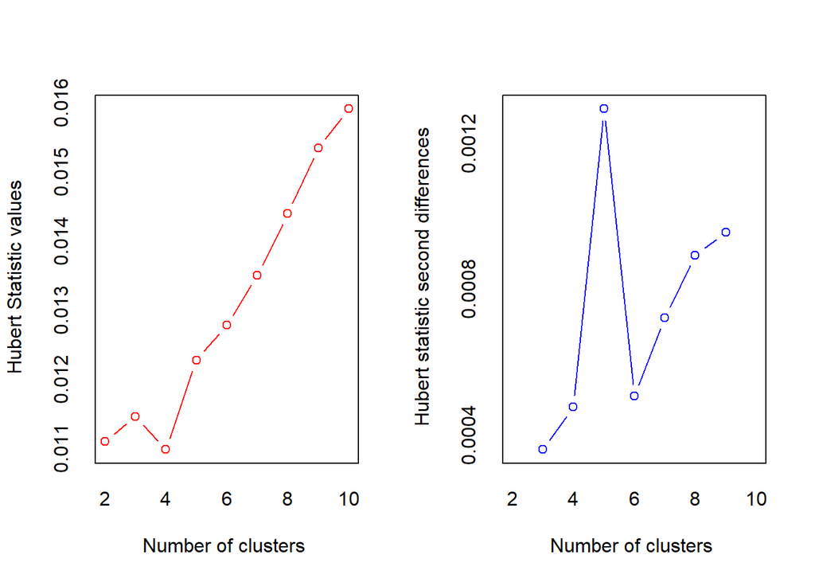

```
## *** : The Hubert index is a graphical method of determining the number of clusters.
##                 In the plot of Hubert index, we seek a significant knee that corresponds to a
##                 significant increase of the value of the measure i.e the significant peak in Hubert
##                 index second differences plot.
##
```

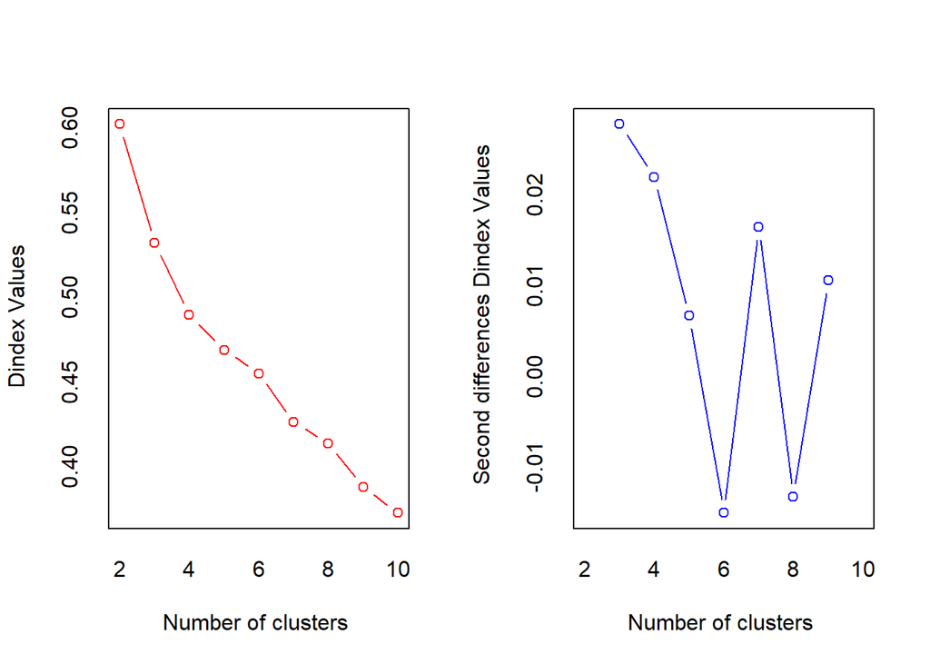

```
## *** : The D index is a graphical method of determining the number of clusters.
##                 In the plot of D index, we seek a significant knee (the significant peak in Dindex
##                 second differences plot) that corresponds to a significant increase of the value of
##                 the measure.
##
## * Among all indices:
## * 9 proposed 2 as the best number of clusters
## * 6 proposed 3 as the best number of clusters
## * 2 proposed 5 as the best number of clusters
## * 1 proposed 6 as the best number of clusters
## * 1 proposed 8 as the best number of clusters
## * 2 proposed 9 as the best number of clusters
## * 3 proposed 10 as the best number of clusters
##
##                    ***** Conclusion *****
##
## * According to the majority rule, the best number of clusters is  2
##
##
```

```r
# Extract MCA coordinates of the individuals
mca_coords <- res.mca1$ind$coord

# Load the NbClust package
library(NbClust)

# Set the number of repetitions for stability analysis
set.seed(123)  # for reproducibility
num_reps <- 10

# Compute the optimal number of clusters using NbClust
nbclust_result <- NbClust(mca_coords, diss = NULL, min.nc = 2, max.nc = 10,
                          method = "kmeans", index = "all", alphaBeale = 0.1)
```

```r
# Get the optimal number of clusters based on the majority rule
optimal_clusters <- nbclust_result$Best.nc[1]

# Print the optimal number of clusters
cat("Optimal number of clusters:", optimal_clusters, "\n")
```

```
## Optimal number of clusters: 2
```

```r
##more parameters related to clusters
Index<-nbclust_result$All.index
Index
```

```
##        KL       CH Hartigan     CCC     Scott   Marriot    TrCovW   TraceW
## 2  2.9006 159.4464  76.8683  0.9383  551.9975 120794838 1213.8749 165.1626
## 3  1.5565 135.2302  52.1119  1.0091  897.9486 102001977  855.4002 135.4905
## 4  0.5575 120.6016  49.7556  2.0673 1124.7035  95391673  545.6230 117.9315
## 5  2.2659 115.4536  33.9127  3.8917 1375.1075  73326258  416.9826 103.2164
## 6  0.5798 107.8355  35.4355  4.5458 1541.5392  65896396  393.5751  94.0510
## 7  0.4287 104.6431  52.6573  5.9088 1692.8733  58421081  291.3604  85.3365
## 8  1.1991 110.5466  46.7887  9.9297 1978.3050  33992878  196.7579  74.0647
## 9  2.5655 115.3598  26.8572 13.2905 2282.4206  18177781  142.0996  65.2196
## 10 2.3762 113.2019  18.4372 14.2098 2367.5629  17632162  124.5248  60.4965
##    Friedman  Rubin Cindex     DB Silhouette   Duda Pseudot2   Beale Ratkowsky
## 2    3.7207 1.4543 0.2652 1.1589     0.4279 2.7595 -95.0054 -1.9629    0.1464
## 3    5.1233 1.7727 0.2177 1.6454     0.3186 1.0054  -0.8174 -0.0165    0.2464
## 4    6.1588 2.0367 0.2238 1.5355     0.2846 0.7481  34.6846  1.0436    0.2674
## 5    7.0857 2.3271 0.1859 1.4944     0.3298 1.3358 -16.5917 -0.7720    0.2963
## 6    8.0231 2.5538 0.2203 1.4275     0.2876 2.2264 -55.6355 -1.6881    0.2967
## 7    9.0132 2.8146 0.2201 1.3625     0.2750 0.5715  89.9805  2.3113    0.2843
## 8   12.5536 3.2430 0.2231 1.2841     0.2345 1.0475  -2.3592 -0.1392    0.2802
## 9   15.4184 3.6828 0.2138 1.2319     0.2436 2.0697 -31.5267 -1.5800    0.2759
## 10  16.0251 3.9703 0.2095 1.1811     0.2549 1.8915 -31.5787 -1.4431    0.2661
##       Ball Ptbiserial    Frey McClain   Dunn Hubert SDindex Dindex   SDbw
## 2  82.5813     0.5672  1.4298  0.2296 0.0607 0.0111  5.3971 0.6019 0.7482
## 3  45.1635     0.5567  2.6350  0.7303 0.0547 0.0115  5.9872 0.5318 0.7267
## 4  29.4829     0.4692 -0.3894  1.2682 0.0591 0.0110  5.7107 0.4894 0.5714
## 5  20.6433     0.5812  2.9628  1.0752 0.0583 0.0123  5.9558 0.4689 0.6958
## 6  15.6752     0.5272  4.6488  1.3948 0.0773 0.0128  6.1712 0.4550 0.6633
## 7  12.1909     0.4570 -0.1565  1.9637 0.0723 0.0135  6.0093 0.4261 0.4415
## 8   9.2581     0.4785  0.8299  1.8896 0.0773 0.0144  7.6336 0.4136 0.4567
## 9   7.2466     0.4516  0.8397  2.2376 0.0756 0.0153  7.0906 0.3879 0.3414
## 10  6.0496     0.4241  0.5066  2.6448 0.0782 0.0159  6.8390 0.3727 0.2957
```

```r
##critical values
cric_val<-nbclust_result$All.CriticalValues
cric_val
```

```
##    CritValue_Duda CritValue_PseudoT2 Fvalue_Beale
## 2          0.6374            84.7619       1.0000
## 3          0.6836            70.8151       1.0000
## 4          0.6901            46.2456       0.3912
## 5          0.6206            40.3531       1.0000
## 6          0.6080            65.1117       1.0000
## 7          0.6463            65.6580       0.0439
## 8          0.6133            32.7920       1.0000
## 9          0.5934            41.7988       1.0000
## 10         0.6025            44.2121       1.0000
```

```r
##best partition
best_part<-nbclust_result$Best.partition
best_part
```

```
##   1   2   3   4   5   6   7   8   9  10  11  12  13  14  15  16  17  18  19  20
##   2   1   2   2   2   2   2   1   2   1   2   2   2   2   2   1   1   2   1   2
##  21  22  23  24  25  26  27  28  29  30  31  32  33  34  35  36  37  38  39  40
##   2   2   2   2   2   2   2   2   2   2   2   2   2   2   2   2   2   2   2   2
##  41  42  43  44  45  46  47  48  49  50  51  52  53  54  55  56  57  58  59  60
##   2   2   2   2   2   2   2   2   2   2   2   2   2   2   2   2   2   2   2   2
##  61  62  63  64  65  66  67  68  69  70  71  72  73  74  75  76  77  78  79  80
##   2   2   2   2   2   2   2   2   2   2   2   2   2   2   2   2   2   2   1   2
##  81  82  83  84  85  86  87  88  89  90  91  92  93  94  95  96  97  98  99 100
##   2   2   2   2   2   2   2   2   2   2   2   2   2   2   2   2   2   2   2   2
## 101 102 103 104 105 106 107 108 109 110 111 112 113 114 115 116 117 118 119 120
##   2   2   2   2   2   2   2   2   2   2   2   2   2   2   2   2   2   2   2   2
## 121 122 123 124 125 126 127 128 129 130 131 132 133 134 135 136 137 138 139 140
##   2   2   2   2   2   2   2   2   2   1   2   2   2   2   2   2   2   2   2   2
## 141 142 143 144 145 146 147 148 149 150 151 152 153 154 155 156 157 158 159 160
```

[output cut: 21 more lines]

```r
##get the metrics
metrics<-nbclust_result$Best.nc
metrics
```

```
##                     KL       CH Hartigan     CCC    Scott  Marriot   TrCovW
## Number_clusters 2.0000   2.0000   3.0000 10.0000   3.0000        9   3.0000
## Value_Index     2.9006 159.4464  24.7564 14.2098 345.9511 15269476 358.4747
##                  TraceW Friedman   Rubin Cindex     DB Silhouette   Duda
## Number_clusters  3.0000   8.0000  9.0000 5.0000 2.0000     2.0000 2.0000
## Value_Index     12.1132   3.5404 -0.1523 0.1859 1.1589     0.4279 2.7595
##                 PseudoT2   Beale Ratkowsky    Ball PtBiserial  Frey McClain
## Number_clusters   2.0000  2.0000    6.0000  3.0000     5.0000 3.000  2.0000
## Value_Index     -95.0054 -1.9629    0.2967 37.4178     0.5812 2.635  0.2296
##                    Dunn Hubert SDindex Dindex    SDbw
## Number_clusters 10.0000      0  2.0000      0 10.0000
## Value_Index      0.0782      0  5.3971      0  0.2957
```

The best number of clusters is 2 according to the majority rule. The values associated with the metrics are also shown in the output above.

**K-means clustering**

K-means clustering is a popular unsupervised machine learning algorithm used for partitioning a dataset into K distinct clusters. It is a simple yet effective algorithm that aims to group similar data points together based on their feature similarities.K-means clustering is widely used in various fields for tasks such as customer segmentation, image compression, anomaly detection, and recommendation systems. However, it has some limitations, such as sensitivity to the initial centroid selection and being prone to converging to local optima. Several variations and improvements to the basic K-means algorithm have been proposed to address these limitations.

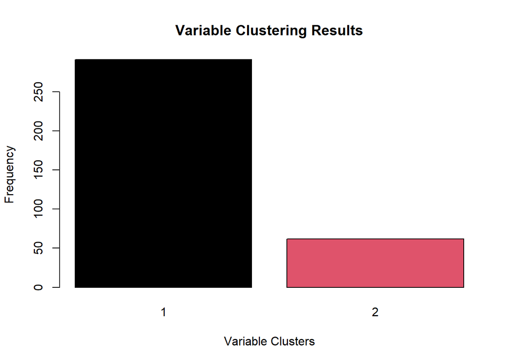

```r
# Perform K-means clustering on the MCA coordinates of variables
set.seed(123)  # for reproducibility
kmeans_result <- kmeans(mca_coords, centers = optimal_clusters)
variable_cluster_assignments <- kmeans_result$cluster

# Create a bar plot of the variable clustering results
barplot(table(variable_cluster_assignments), col = 1:optimal_clusters,
        xlab = "Variable Clusters", ylab = "Frequency", main = "Variable Clustering Results")
```

The optimal number of clusters is 2 and hence the analysis continues to investigate the variables contributing to the two clusters.

**Dendrogram**

Dendrogram is a tree that is used to visualize the objects in the different clusters.

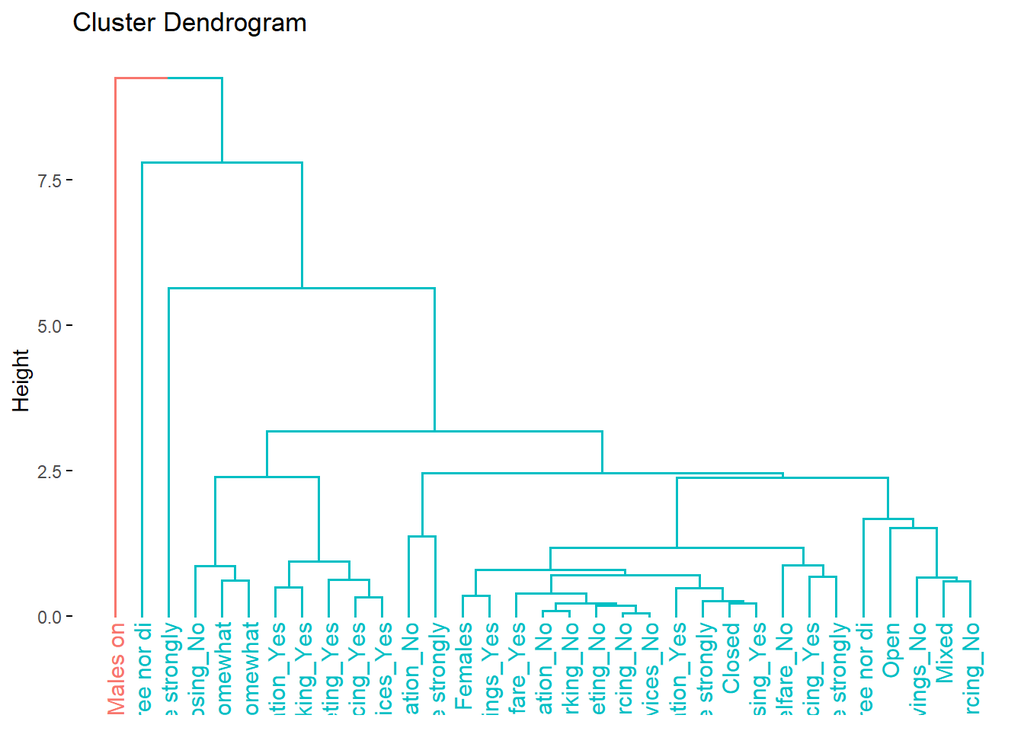

```r
# Extract coordinates of categories
coord <- res.mca1$var$coord

# Perform variable clustering using MCA results
hc <- hclust(dist(coord))

clustering_res <- cutree(hc,k=2)  # Adjust the number of clusters as needed

# Plot variable clustering dendrogram
fviz_dend(hc, k = 2, cex = 0.8)
```

**Finding the clusters**

```r
# Extract MCA coordinates of the variables
mca_coords <- res.mca1$var$coord

# Perform K-means clustering on the MCA coordinates of variables
k <- optimal_clusters
set.seed(123)  # for reproducibility
kmeans_result <- kmeans(mca_coords, centers = k)
variable_cluster_assignments <- kmeans_result$cluster

# Create a data frame with variable names and their cluster assignments
variable_clusters <- data.frame(Variable = rownames(mca_coords), Cluster = variable_cluster_assignments)

# Compute summary statistics by cluster
summary_stats <- aggregate(Variable ~ Cluster, data = variable_clusters, FUN = function(x) paste(unique(x), collapse = ", "))

# Print the summary statistics
data.table(summary_stats)
```

```
##    Cluster
## 1:       1
## 2:       2
##                                                                                                                                                                                                                                                                                                          …
## 1: Registration_Yes, Closed, Open, Females, Males on, Mixed, Amalgamation_No, Social_networking_No, Input_sourcing_No, Output_marketing_No, Extension_services_No, Credit_sourcing_No, Credit_sourcing_Yes, Savings_No, Savings_Yes, Social_welfare_No, Social_welfare_Yes, Fine_imposing_Yes, Members_tr…
## 2:                                                                                                                                                                                                                                                                                       Registration_No,…
```

The clusters are shown in the results above and the analysis continues to check the summary statistics of the clusters.

**Summary statistics of the clusters**

```r
# Assuming you have performed MCA and obtained the MCA results in 'mca_result'
# Assuming you have obtained the cluster membership in 'cluster_membership'
# Perform variable clustering using k-means algorithm on MCA results
num_clusters <- 2 # Specify the number of clusters
clusters <- kmeans(res.mca1$var$coord, centers = num_clusters)

# Cluster membership of each variable
cluster_membership <- clusters$cluster
# Combine cluster membership and variable coordinates
data <- data.frame(cluster_membership, res.mca1$var$coord)

# Calculate mean and standard deviation of variables in each cluster
means <- aggregate(. ~ cluster_membership, data, FUN = mean)
# Calculate standard deviation for clusters with at least 2 non-NA values
sds <- aggregate(. ~ cluster_membership, data, FUN = function(x) {
  if (sum(!is.na(x)) >= 2) {
    sd(x, na.rm = TRUE)
  } else {
    0
  }
})


# Print the means and standard deviations
print("Means:")
```

```
## [1] "Means:"
```

```r
print(means)
```

```
##   cluster_membership       Dim.1     Dim.2      Dim.3      Dim.4      Dim.5
## 1                  1 -0.06810927 0.1887170 -0.0309520 -0.2580567  0.2090524
## 2                  2  0.93271412 0.2655841  0.5996715  0.6124942 -0.2872791
```

```r
print("Standard Deviations:")
```

```
## [1] "Standard Deviations:"
```

```r
print(sds)
```

```
##   cluster_membership     Dim.1     Dim.2     Dim.3     Dim.4     Dim.5
## 1                  1 0.3725776 0.5961527 0.3874165 0.9429293 1.3836601
## 2                  2 0.9590055 0.8187519 1.3042628 0.9366201 0.4189032
```

```r
# Extract the coordinates of the individuals from the MCA results
individual_coordinates <- res.mca1$ind$coord

# Perform K-means clustering on the individual coordinates
k <- 2 # Number of clusters
clusters <- kmeans(individual_coordinates, centers = k)

# Get the cluster assignments for each individual
individual_clusters <- clusters$cluster

# Combine individual cluster assignments with the original dataframe
data <- data.frame(individual_clusters, my_data)

# Combine individual cluster assignments with the original dataframe
data <- data.frame(individual_clusters, my_data)
# Convert all variables to factors
data <- data %>%
  mutate_all(as.factor)

##write out the csv file
write.csv(data,"clustered_data.csv")
```

**Summary statistics of variables**

```r
# Group by the grouping column and calculate the proportion of each factor level
##Registration
 data %>%
  count(individual_clusters, Registration) %>%
  group_by(individual_clusters) %>%
  mutate(proportion = n / sum(n))
```

```
## # A tibble: 4 × 4
## # Groups:   individual_clusters [2]
##   individual_clusters Registration     n proportion
##   <fct>               <fct>        <int>      <dbl>
## 1 1                   No               1     0.0161
## 2 1                   Yes             61     0.984
## 3 2                   No              44     0.151
## 4 2                   Yes            247     0.849
```

```r
# Print the summary statistics
print(summary_stats)
```

```
##   Cluster
## 1       1
## 2       2
##                                                                                                                                                                                                                                                                                                          …
## 1 Registration_Yes, Closed, Open, Females, Males on, Mixed, Amalgamation_No, Social_networking_No, Input_sourcing_No, Output_marketing_No, Extension_services_No, Credit_sourcing_No, Credit_sourcing_Yes, Savings_No, Savings_Yes, Social_welfare_No, Social_welfare_Yes, Fine_imposing_Yes, Members_tru…
## 2                                                                                                                                                                                                                                                                                       Registration_No, …
```

```r
##membership entry criteria
data %>%
  count(individual_clusters,Membership_entry_criteria) %>%
  mutate(proportion = n / sum(n))
```

```
##   individual_clusters Membership_entry_criteria   n proportion
## 1                   1                    Closed  54 0.15297450
## 2                   1                      Open   8 0.02266289
## 3                   2                    Closed 257 0.72804533
## 4                   2                      Open  34 0.09631728
```

```r
##Members gender
data %>%
  count(individual_clusters,Members_Gender) %>%
  mutate(proportion = n / sum(n))
```

```
##   individual_clusters Members_Gender   n  proportion
## 1                   1        Females   1 0.002832861
## 2                   1          Mixed  61 0.172804533
## 3                   2        Females 191 0.541076487
## 4                   2       Males on   5 0.014164306
## 5                   2          Mixed  95 0.269121813
```

```r
##Amalgamation
data %>%
  count(individual_clusters,Amalgamation) %>%
  mutate(proportion = n / sum(n))
```

```
##   individual_clusters Amalgamation   n proportion
## 1                   1           No  19 0.05382436
## 2                   1          Yes  43 0.12181303
## 3                   2           No 273 0.77337110
## 4                   2          Yes  18 0.05099150
```

```r
##socialnetworking
data %>%
  count(individual_clusters,Social_networking) %>%
  mutate(proportion = n / sum(n))
```

```
##   individual_clusters Social_networking   n proportion
## 1                   1                No  16 0.04532578
## 2                   1               Yes  46 0.13031161
## 3                   2                No 249 0.70538244
## 4                   2               Yes  42 0.11898017
```

```r
##input sourcing
data %>%
  count(individual_clusters,Input_sourcing) %>%
  mutate(proportion = n / sum(n))
```

```
##   individual_clusters Input_sourcing   n proportion
## 1                   1             No  24 0.06798867
## 2                   1            Yes  38 0.10764873
## 3                   2             No 284 0.80453258
## 4                   2            Yes   7 0.01983003
```

```r
##Output marketing
data %>%
  count(individual_clusters,Output_marketing) %>%
  mutate(proportion = n / sum(n))
```

```
##   individual_clusters Output_marketing   n proportion
## 1                   1               No   6 0.01699717
## 2                   1              Yes  56 0.15864023
## 3                   2               No 282 0.79886686
## 4                   2              Yes   9 0.02549575
```

```r
##Extension services
data %>%
  count(individual_clusters,Extension_services) %>%
  mutate(proportion = n / sum(n))
```

```
##   individual_clusters Extension_services   n proportion
## 1                   1                 No  27 0.07648725
## 2                   1                Yes  35 0.09915014
## 3                   2                 No 282 0.79886686
## 4                   2                Yes   9 0.02549575
```

```r
##credit sourcing
data %>%
  count(individual_clusters,Credit_sourcing) %>%
  mutate(proportion = n / sum(n))
```

```
##   individual_clusters Credit_sourcing   n proportion
## 1                   1              No  47 0.13314448
## 2                   1             Yes  15 0.04249292
## 3                   2              No 165 0.46742210
## 4                   2             Yes 126 0.35694051
```

```r
##savings
data %>%
  count(individual_clusters,Savings) %>%
  mutate(proportion = n / sum(n))
```

```
##   individual_clusters Savings   n proportion
## 1                   1      No  45 0.12747875
## 2                   1     Yes  17 0.04815864
## 3                   2      No  77 0.21813031
## 4                   2     Yes 214 0.60623229
```

```r
##social welfare
data %>%
  count(individual_clusters,Social_welfare) %>%
  mutate(proportion = n / sum(n))
```

```
##   individual_clusters Social_welfare   n proportion
## 1                   1             No  57 0.16147309
## 2                   1            Yes   5 0.01416431
## 3                   2             No 113 0.32011331
## 4                   2            Yes 178 0.50424929
```

```r
##fine imposing
data %>%
  count(individual_clusters,Fine_imposing) %>%
  mutate(proportion = n / sum(n))
```

```
##   individual_clusters Fine_imposing   n proportion
## 1                   1            No  19 0.05382436
## 2                   1           Yes  43 0.12181303
## 3                   2            No  20 0.05665722
## 4                   2           Yes 271 0.76770538
```

```r
##members trust
data %>%
  count(individual_clusters,Members_trust) %>%
  mutate(proportion = n / sum(n))
```

```
##   individual_clusters        Members_trust   n  proportion
## 1                   1       Agree somewhat  22 0.062322946
## 2                   1       Agree strongly  39 0.110481586
## 3                   1    Disagree strongly   1 0.002832861
## 4                   2       Agree somewhat  48 0.135977337
## 5                   2       Agree strongly 233 0.660056657
## 6                   2    Disagree strongly   3 0.008498584
## 7                   2 Neither agree nor di   7 0.019830028
```

```r
##other groups trust
data %>%
  count(individual_clusters,Other_groups_trust) %>%
  mutate(proportion = n / sum(n))
```

```
##   individual_clusters   Other_groups_trust   n proportion
## 1                   1       Agree somewhat  26 0.07365439
## 2                   1       Agree strongly  27 0.07648725
## 3                   1    Disagree strongly   5 0.01416431
## 4                   1 Neither agree nor di   4 0.01133144
## 5                   2       Agree somewhat  74 0.20963173
## 6                   2       Agree strongly 118 0.33427762
## 7                   2    Disagree strongly  46 0.13031161
## 8                   2 Neither agree nor di  53 0.15014164
```

The proportions of each variable in the different clusters is shown in the outputs above.